# FOMC Word Watcher

christoffer.nordenlow@outlook.com

## Text mining FOMC Minutes 2020-11-05

*Below analysis aims to give colour on FOMC Minutes in terms of the overall sentiment as well as which topics and words that are hot and cold.*

*To be able to to compare Minutes by different length with each other, everything below is set in relation to total the number of words or paragraph in their respective Minutes. Please see more information at description and methodology.*

*Contents include:*

General sentiment

Topic analysis

Policy action and topics

In deeper breakdown of inflation and Asset Purchases

### General sentiment

#### Net sentiment

*Net sentiment is calculated by extracting all positive and negative words, and then taking the difference between these divided by total number of words.*

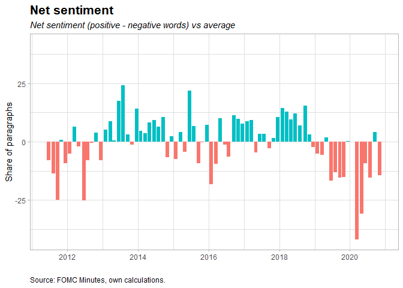

#### Sentiment words

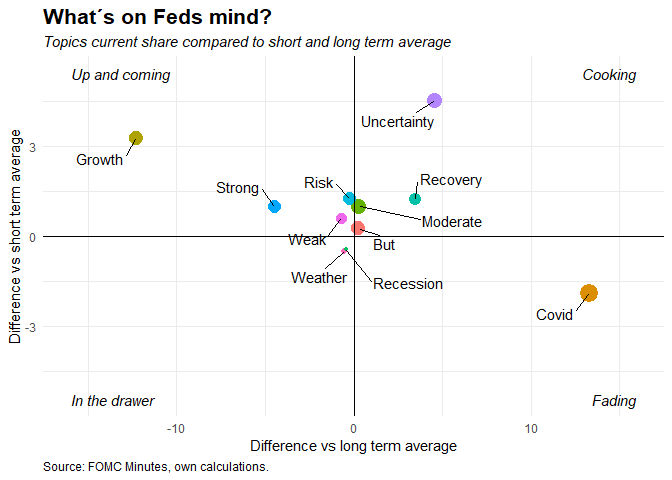

#### Conditions-O-Meters

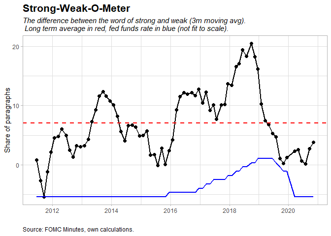

### Topic analysis

#### General topics

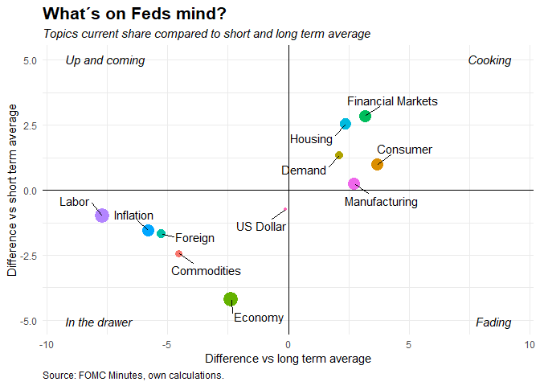

#### Sentiment per topic

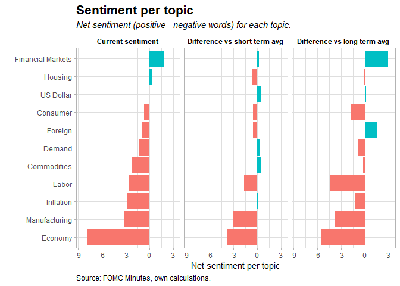

### Policy action and topics

#### Policy tool box

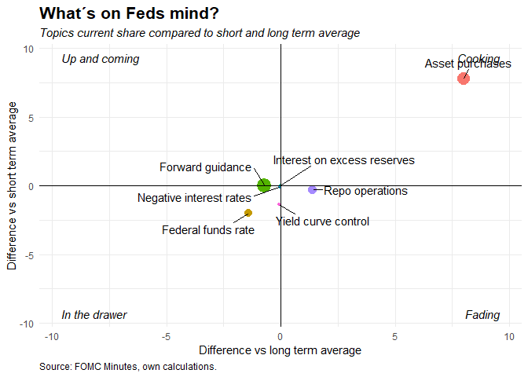

#### Policy key words

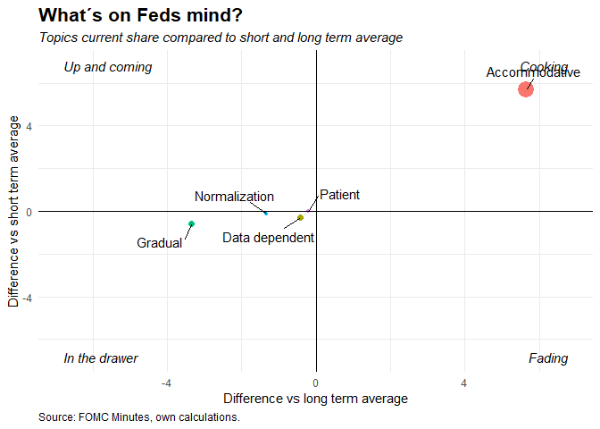

#### Key-words-O-Meters

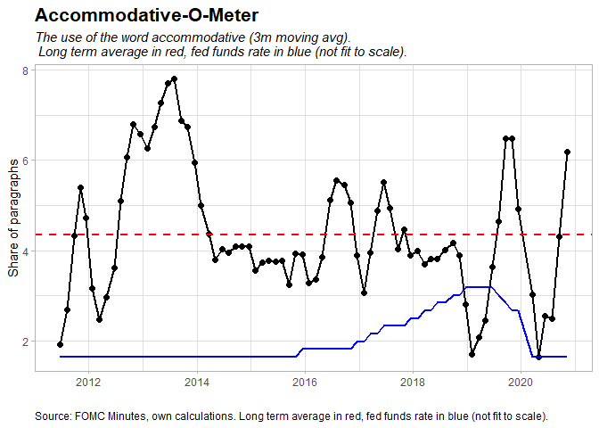

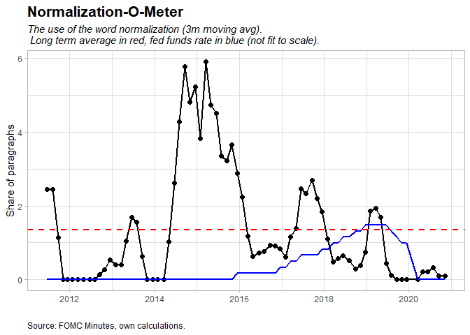

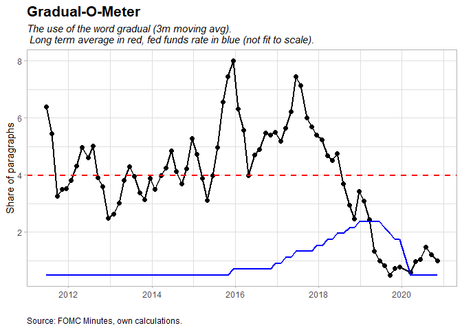

#### Policy action

*The graph below show the difference between sentences containing words like consensus, majority, all and those of words like a few, one or two. Above red dotted line suggest there are a more consensus view among participants then when below the dotted red line.*

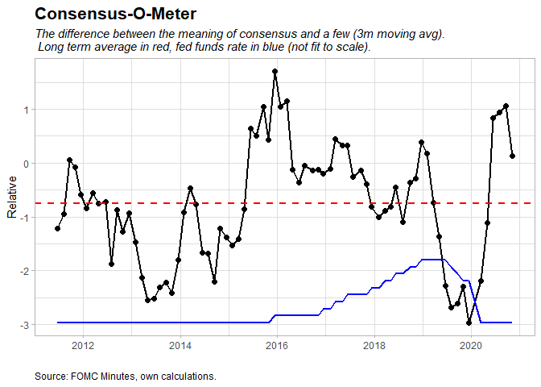

### In deeper breakdown

#### Inflation

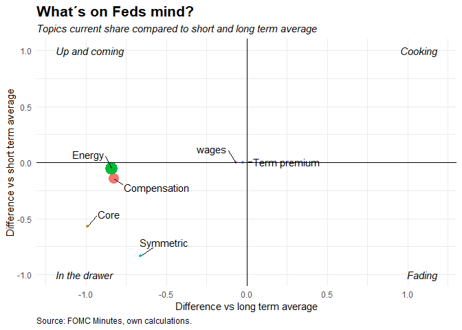

#### Asset Program

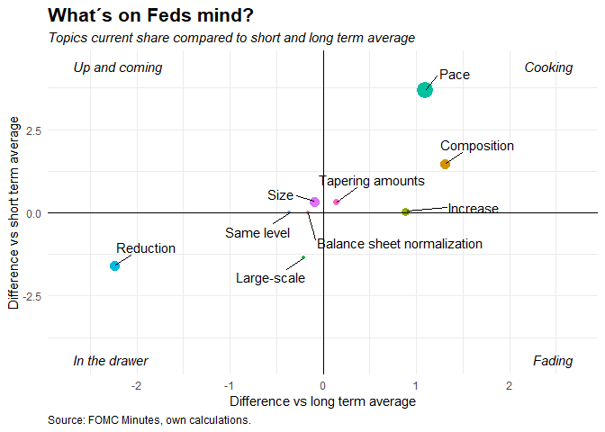

### Description and Methodology

Please see more information on my *[github](https://github.com/cnordenlow/fomc-word-watcher)*.

**Methodology**  
The approach of this project are as follows.

- Words and topics are divided into bag of words of its meaning (e.g. the word “strong” may consists of [“strong”, “stronger”, “strongest”, “strengthen”]).
- All text are divided into sentences that cleaned for special characters, extra spaces, stop words and then tokenized and lemmatized, then converted back to it´s sentence.
- All sentences are then iterated where it checks for the different bag of words and then counted, (e.g. if the word “stronger” is found in a sentence, the count adds one.) For some topics, a second loop are then iterated where it counts negative and positive words in the same meaning to get the net sentence.

The methodology used in this project include use of Python for web parsing and the package of NLTK for text mining. The data is then transfered to R for some additional calculations and to provide vizualisations in R Markdown. Some notes below of the different parts.

*Web parsing*  
All web parsing is done using BEautifulSoup package. THe code first parse all .htm pages with the url of “Minutes” in it. Then, a second loop parse all the (chosen) Minutes for the text mining. In both parsing steps, there are a time delay of a couple of seconds.